# R dyntrace report

K. Siek, A. Goel

# 1 Dataset

| key | value | occurances |
| --- | --- | --- |
| GIT_COMMIT_INFO | fd876fcbd8f6e4a651c772812d8e711212879efe Merge branch ‘master’ of github.com:PRL-PRG/promisedyntracer | 754 |
| R_COMPILE_PKGS | 1 | 754 |
| R_DISABLE_BYTECODE | 1 | 754 |
| R_ENABLE_JIT | 0 | 754 |
| R_KEEP_PKG_SOURCE | yes | 754 |
| RDT_COMPILE_VIGNETTE | false | 754 |

| packages | vignettes |
| --- | --- |
| 1 | 1 |

# 2 Overview

| package | functions | calls | promises | promise accesses | promise forces | promise lookups |
| --- | --- | --- | --- | --- | --- | --- |
| * | 36k | 0 | 0 | 0 | 0 | 0 |
| ?-? | 0 | 0 | 0 | 0 | 0 | 0 |

**promise force** means the promise is accessed and the code of the promise is executed  
**promise lookup** mean the promise is accessed and the code of the promise is not executed

# 3 Promise accesses

| classification | number | percentage |
| --- | --- | --- |
| accessed 1+ times, never forced | 30m | 0.92% |
| accessed 2+ times, forced 2+ times | 0 | 0.00% |
| accessed 2+ times, forced once | 530m | 16.01% |
| accessed once, forced once | 2.1b | 66.12% |
| never accessed | 561m | 16.95% |

**promise force** means the promise is accessed and the code of the promise is executed  
**promise lookup** mean the promise is accessed and the code of the promise is not executed

# 4 Number of accesses to a promise

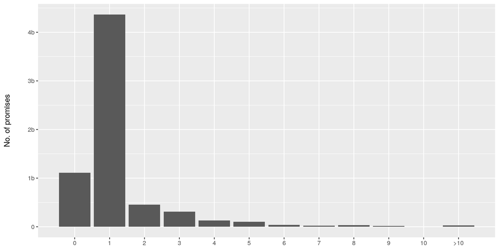

| no. of evaluations | number | percentage |
| --- | --- | --- |
| 0 | 1.1b | 16.76% |
| 1 | 4.3b | 65.98% |
| 2 | 456.7m | 6.90% |
| 3 | 312.4m | 4.72% |
| 4 | 132.2m | 2.00% |
| 5 | 100.8m | 1.52% |
| 6 | 39.1m | 0.59% |
| 7 | 22.7m | 0.34% |
| 8 | 33.3m | 0.50% |
| 9 | 16.2m | 0.25% |
| 10 | 1.8m | 0.03% |
| >10 | 27.4m | 0.42% |

Promise types follow the type designations in `Rinternals.h`.

# 5 Promise code types

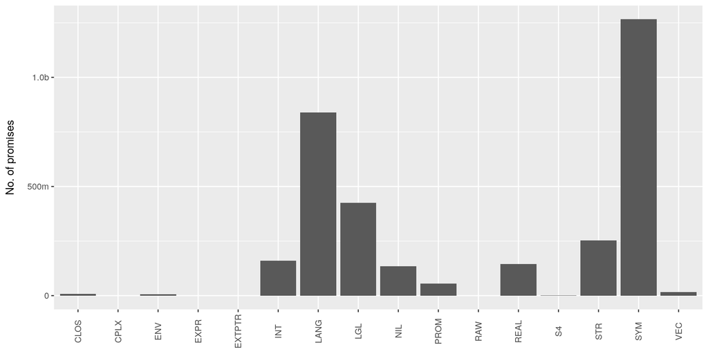

| promise code type | number | percentage |
| --- | --- | --- |
| SYM | 1.2b | 38.26% |
| LANG | 838.3m | 25.33% |
| LGL | 425.8m | 12.87% |
| STR | 252.6m | 7.63% |
| INT | 160.1m | 4.84% |
| REAL | 145.3m | 4.39% |
| NIL | 134.9m | 4.08% |
| PROM | 54.9m | 1.66% |
| VEC | 15.6m | 0.47% |
| CLOS | 7.6m | 0.23% |
| ENV | 6.5m | 0.20% |
| S4 | 1.4m | 0.05% |
| RAW | 23.6k | 0.00% |
| EXTPTR | 4.5k | 0.00% |
| EXPR | 242 | 0.00% |
| CPLX | 18 | 0.00% |

Promise types follow the type designations in `Rinternals.h`.

# 6 Type traces

| number | percent | type trace |
| --- | --- | --- |
| 838.3m | 25.33% | LANG |
| 425.8m | 12.87% | LGL |
| 252.6m | 7.63% | STR |
| 195.9m | 5.92% | SYM→PROM→LANG |
| 160.1m | 4.84% | INT |
| 145.3m | 4.39% | REAL |
| 134.9m | 4.08% | NIL |
| 124.5m | 3.76% | SYM→PROM→SYM |
| 109.2m | 3.30% | SYM |
| 98.2m | 2.97% | SYM→REAL |
| 95.2m | 2.88% | SYM→STR |
| 78.8m | 2.38% | SYM→PROM→STR |
| 67.9m | 2.05% | SYM→ENV |
| 61.4m | 1.86% | SYM→VEC |
| 54.6m | 1.65% | SYM→INT |
| 38.4m | 1.16% | SYM→PROM→SYM→PROM→LANG |
| 36.1m | 1.09% | PROM→SYM |
| 35.0m | 1.06% | SYM→PROM→SYM→PROM→SYM |
| 29.1m | 0.88% | SYM→PROM→SYM→STR |
| 24.4m | 0.74% | SYM→PROM→REAL |
| 22.1m | 0.67% | SYM→PROM→LGL |
| 18.9m | 0.57% | SYM→PROM→SYM→ENV |
| 16.2m | 0.49% | SYM→PROM→SYM→PROM→SYM→ENV |
| 15.6m | 0.47% | VEC |
| 14.5m | 0.44% | SYM→PROM→PROM→SYM |
| 13.7m | 0.42% | SYM→PROM→SYM→VEC |
| 13.2m | 0.40% | SYM→PROM→ENV |
| 12.2m | 0.37% | SYM→PROM→SYM→PROM→REAL |
| 12.0m | 0.36% | SYM→PROM→SYM→REAL |
| 11.3m | 0.34% | SYM→PROM→SYM→PROM→STR |

[output cut: 607 more lines]

Promise types follow the type designations in `Rinternals.h`.  
**α** indicates that the promise contains the expression of type **α**.  
**PROM→α** indicates that the promise contains a promise which contains the expression of type **α**, etc.  
**BCODE →α** indicates that it’s a byte-compiled expression that was originally of type **α**.  
**SYM→α** indicates that it’s a symbol that points to an expression of type **α**.  
**…** is a type that could not has not been correctly determined.

# 7 Promise return types

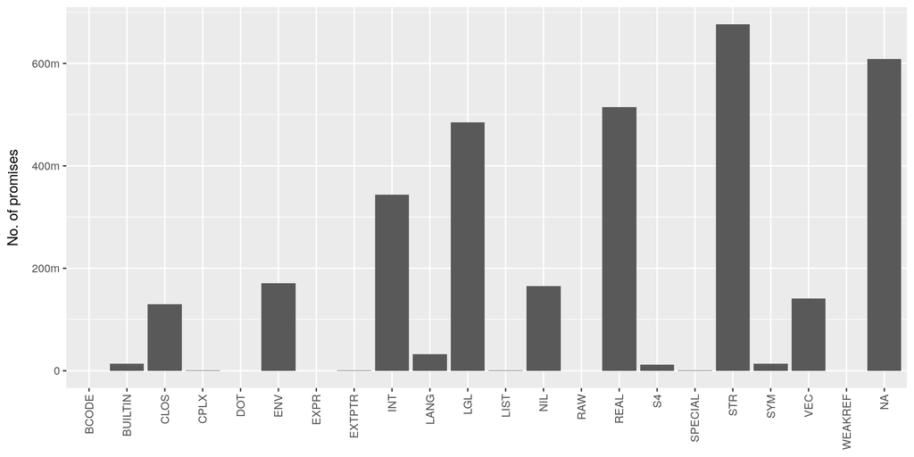

| promise code type | number | percentage |
| --- | --- | --- |
| STR | 676.4m | 20.44% |
| NA | 608.8m | 18.40% |
| REAL | 515.2m | 15.57% |
| LGL | 485.1m | 14.66% |
| INT | 343.8m | 10.39% |
| ENV | 170.7m | 5.16% |
| NIL | 165.3m | 4.99% |
| VEC | 141.4m | 4.27% |
| CLOS | 129.5m | 3.91% |
| LANG | 32.0m | 0.97% |
| SYM | 13.5m | 0.41% |
| BUILTIN | 13.4m | 0.41% |
| S4 | 12.0m | 0.37% |
| CPLX | 747.3k | 0.02% |
| LIST | 411.7k | 0.01% |
| EXTPTR | 404.8k | 0.01% |
| SPECIAL | 318.6k | 0.01% |
| EXPR | 159.9k | 0.00% |
| WEAKREF | 83.0k | 0.00% |
| RAW | 61.8k | 0.00% |
| BCODE | 26.4k | 0.00% |
| DOT | 991 | 0.00% |

# 8 What do specific promises return?

[figure not shown]

Promise types follow the type designations in `Rinternals.h`.  
**α→β** indicates that the promise contains an expression of type **α** which evaluates to an expression of type **β** when the promise is forced.

# 9 Promise forces by types

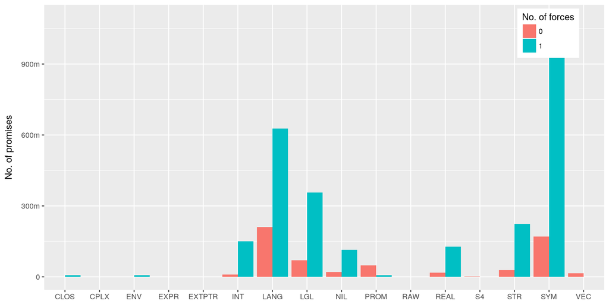

| promise code type | forces | number | percentage |
| --- | --- | --- | --- |
| CLOS | 0 | 789 | 0.01% |
| CLOS | 1 | 7.6m | 99.99% |
| CPLX | 0 | 12 | 66.67% |
| CPLX | 1 | 6 | 33.33% |
| ENV | 0 | 6.5k | 0.10% |
| ENV | 1 | 6.5m | 99.90% |
| EXPR | 0 | 0 | 0% |
| EXPR | 1 | 242 | 100% |
| EXTPTR | 0 | 38 | 0.83% |
| EXTPTR | 1 | 4.5k | 99.17% |
| INT | 0 | 9.1m | 5.71% |
| INT | 1 | 151.0m | 94.29% |
| LANG | 0 | 211m | 25.16% |
| LANG | 1 | 627m | 74.84% |
| LGL | 0 | 70m | 16.33% |
| LGL | 1 | 356m | 83.67% |
| NIL | 0 | 20m | 15.22% |
| NIL | 1 | 114m | 84.78% |
| PROM | 0 | 48.2m | 87.86% |
| PROM | 1 | 6.6m | 12.14% |
| RAW | 0 | 24k | 99.92% |
| RAW | 1 | 19 | 0.08% |
| REAL | 0 | 18m | 12.39% |
| REAL | 1 | 127m | 87.61% |
| S4 | 0 | 1.4m | 97.18% |
| S4 | 1 | 42k | 2.82% |
| STR | 0 | 29m | 11.38% |
| STR | 1 | 224m | 88.62% |
| SYM | 0 | 170m | 13.42% |
| SYM | 1 | 1.0b | 86.58% |
| VEC | 0 | 14.7m | 93.98% |
| VEC | 1 | 946k | 6.02% |

Promise types follow the type designations in `Rinternals.h`.

# 10 Promise evaluation distances

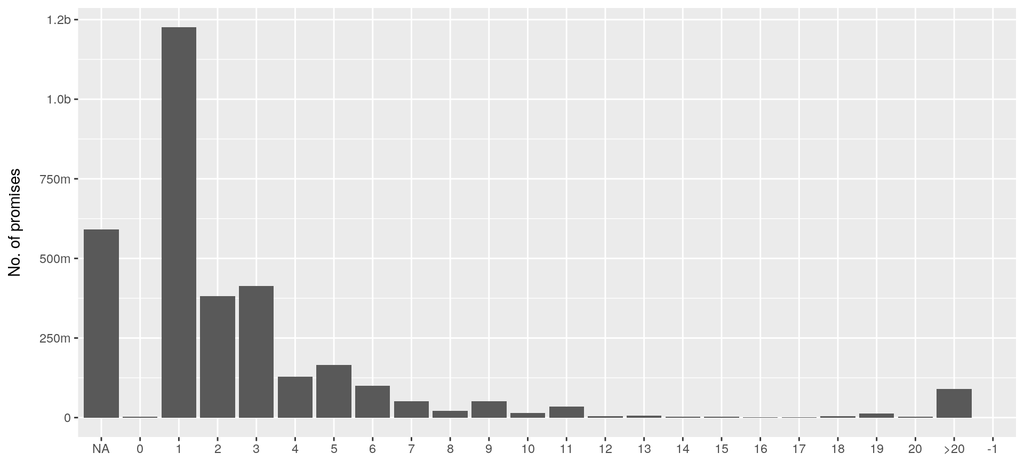

| distance | number | percentage |
| --- | --- | --- |
| -1 | 0 | 0.00% |
| >20 | 90.7m | 2.74% |
| 0 | 2.6m | 0.08% |
| 1 | 1.2b | 37.04% |
| 10 | 14.9m | 0.45% |
| 11 | 34.7m | 1.05% |
| 12 | 4.8m | 0.15% |
| 13 | 6.6m | 0.20% |
| 14 | 2.6m | 0.08% |
| 15 | 2.0m | 0.06% |
| 16 | 1.3m | 0.04% |
| 17 | 460k | 0.01% |
| 18 | 4.1m | 0.13% |
| 19 | 12.3m | 0.37% |
| 2 | 381.8m | 11.54% |
| 20 | 2.0m | 0.06% |
| 3 | 413.1m | 12.48% |
| 4 | 127.8m | 3.86% |
| 5 | 165.1m | 4.99% |
| 6 | 100.5m | 3.04% |
| 7 | 51.5m | 1.56% |
| 8 | 21.4m | 0.65% |
| 9 | 51.4m | 1.55% |
| NA | 591.2m | 17.86% |

**n** - distance from the function for which a promise was created and the function in which it was evaluated  
**NA** - promise was not executed, there is no distance measure (a virgin promise)  
**-1** - promise was executed but there is no path from the origin to the point of evaluation (an escaped promise)

# 11 Interactions among promises

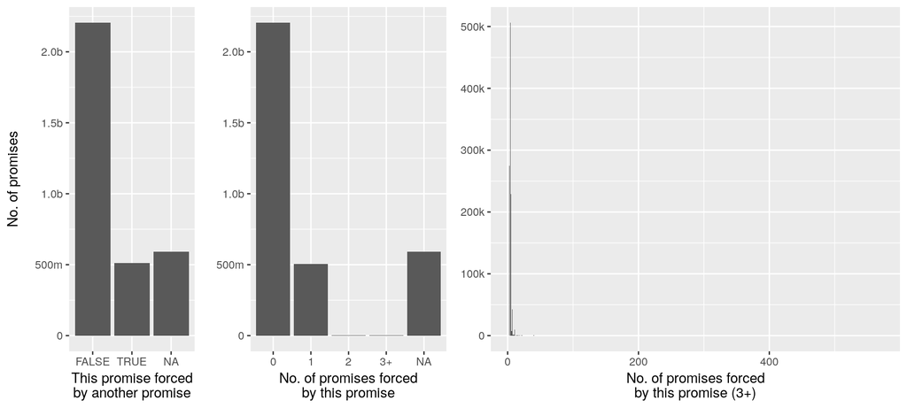

| forced by another promise | number | percentage |
| --- | --- | --- |
| FALSE | 2.2b | 66.66% |
| TRUE | 512m | 15.48% |
| NA | 591m | 17.86% |

| promises that force this many promises | number | percentage |
| --- | --- | --- |
| 0 | 2.2b | 66.76% |
| 1 | 504.7m | 15.27% |
| 2 | 1.4m | 0.04% |
| 3 | 274.4k | 0.01% |
| 4 | 506.3k | 0.02% |
| 5 | 228.9k | 0.01% |
| 6 | 7.2k | 0.00% |
| 7 | 42.2k | 0.00% |
| 8 | 1.2k | 0.00% |
| 9 | 1.1k | 0.00% |
| 10 | 1.1k | 0.00% |
| 11 | 9.9k | 0.00% |
| 12 | 231 | 0.00% |
| 13 | 166 | 0.00% |
| 14 | 409 | 0.00% |
| 15 | 487 | 0.00% |
| 16 | 452 | 0.00% |
| 17 | 336 | 0.00% |
| 18 | 224 | 0.00% |
| 19 | 81 | 0.00% |
| 20 | 231 | 0.00% |
| 21 | 53 | 0.00% |
| 22 | 228 | 0.00% |
| 23 | 51 | 0.00% |
| 24 | 39 | 0.00% |
| 25 | 23 | 0.00% |
| 26 | 15 | 0.00% |
| 27 | 152 | 0.00% |
| 28 | 13 | 0.00% |
| 29 | 65 | 0.00% |

[output cut: 149 more lines]

Promises forced by other promises:  
`TRUE` is when a promise was created within some promise x but was forced within a different promise y.  
`FALSE` is when a promise was forced within the same promise as it was created.  
`NA` means the promise was not forced.

# 12 Calls and functions by type

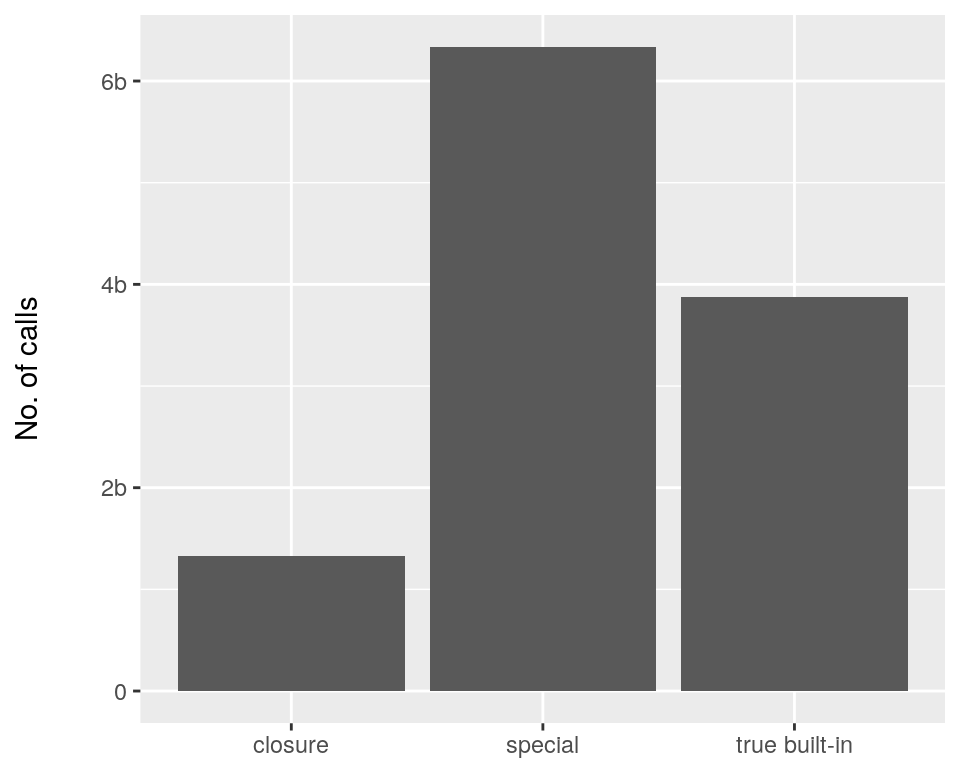

| type | number | percentage |
| --- | --- | --- |
| closure | 1.3b | 11.53% |
| special | 6.3b | 54.91% |
| true built-in | 3.8b | 33.56% |

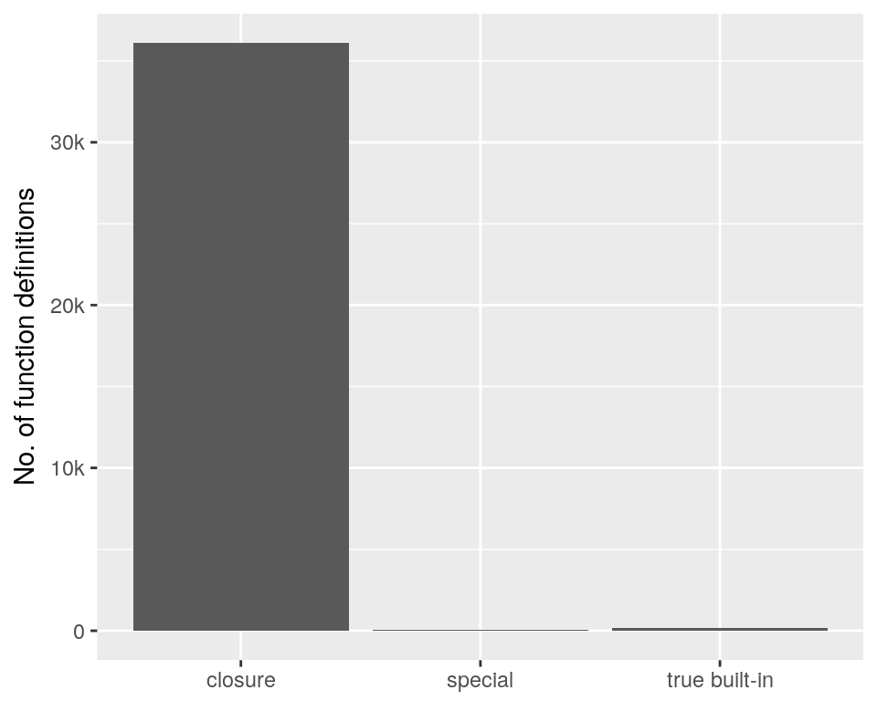

| type | number | percentage |
| --- | --- | --- |
| closure | 36.1k | 99.49% |
| special | 37 | 0.10% |
| true built-in | 148 | 0.41% |

[output not shown]

# 13 Byte-code compilation

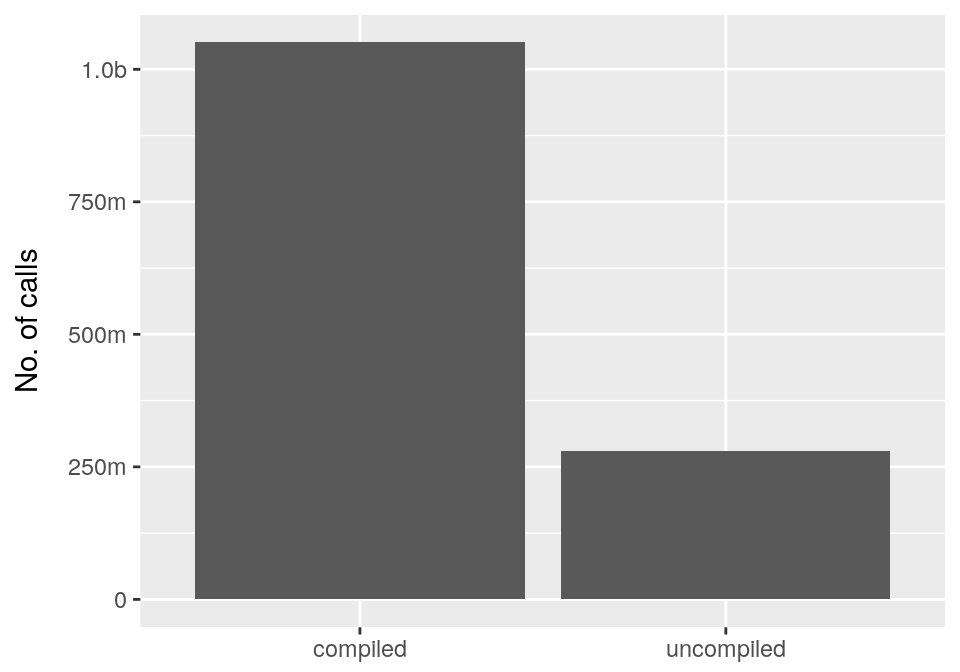

| compiled | number | percentage |
| --- | --- | --- |
| compiled | 1.0b | 78.98% |
| uncompiled | 280m | 21.02% |

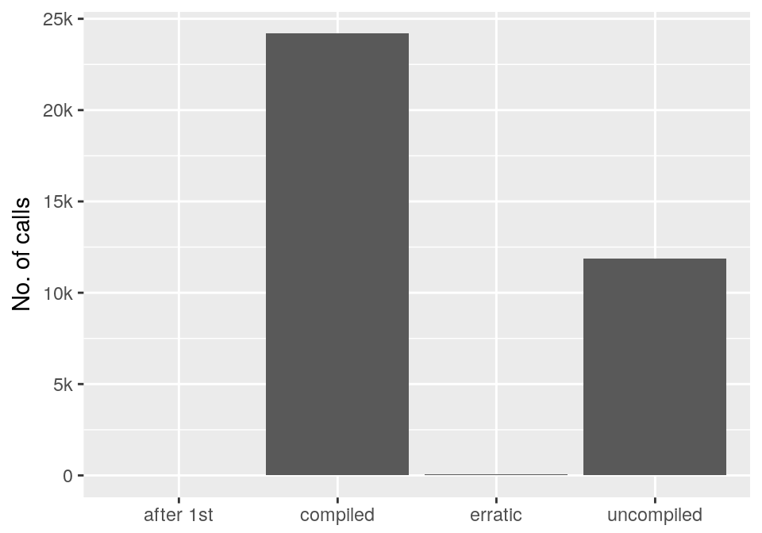

| compiled | number | percentage |
| --- | --- | --- |
| after 1st | 4 | 0.01% |
| compiled | 24k | 66.97% |
| erratic | 68 | 0.19% |
| uncompiled | 12k | 32.83% |

[output not shown]

# 14 Call and function definition strictness

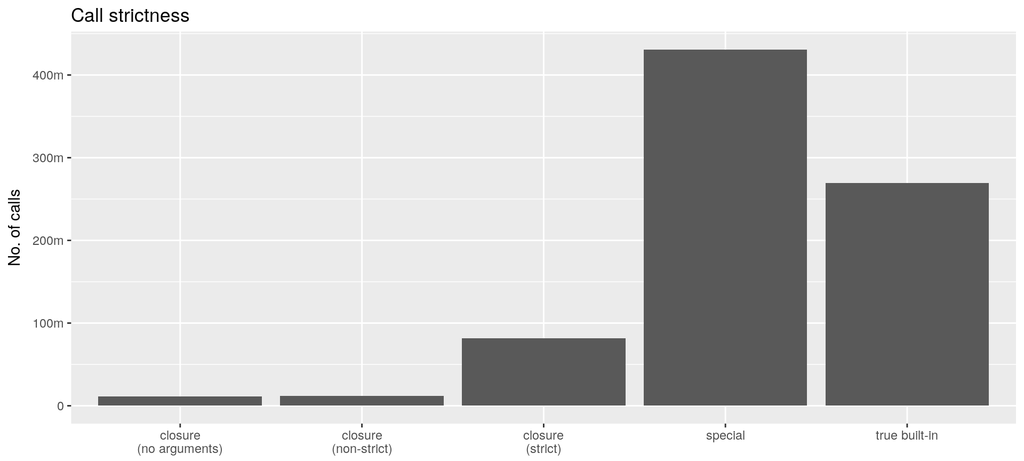

[output not shown]

[figure not shown]

A call is **strict** if all of its arguments are **evaluated** and none of the arguments is **escaped**. (This means that a function may pass unevaluated promises to a child call and still be strict, but it cannot leak the promise).  
A function is **strict** if all of its calls are **strict**. Functions that don’t take promises are neither **strict** nor **non-strict** – these can be either arrity-0 closures or built-in (which accept values rather than promises).

## 14.1 Call strictness ratios

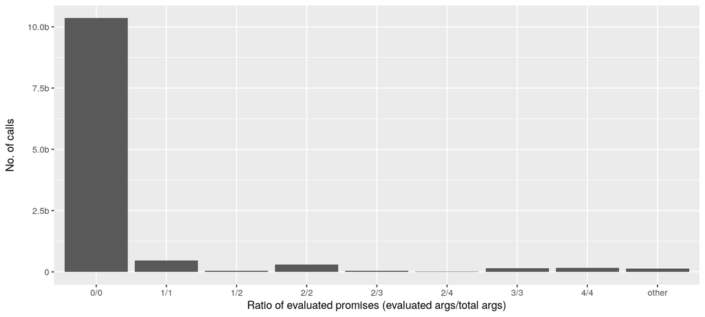

```
## # A tibble: 9 x 2
##   short       number
##   <chr>        <dbl>
## 1 0/0   10356211007.
## 2 1/1     462766140.
## 3 1/2      47541425.
## 4 2/2     299423981.
## 5 2/3      47494006.
## 6 2/4      20273862.
## 7 3/3     142717559.
## 8 4/4     169624720.
## 9 other   128729829.
```

**Strictness ratio** of the form `n/m` means that a call evaluated `n` promises out of `m` promises that were created for it. `0/0` can mean either that a function had no arguments or that it was a built-in etc (had arguments, but they were passed without promises).

**Strictness ratio** of the form `n/m` means that a call evaluated `n` promises out of `m` promises that were created for it. `0/0` can mean either that a function had no arguments or that it was a built-in etc (had arguments, but they were passed without promises).

**Strictness ratio** of the form `n/m` means that a call evaluated `n` promises out of `m` promises that were created for it. `0/0` can mean either that a function had no arguments or that it was a built-in etc (had arguments, but they were passed without promises).